# Week 10 Assignment

Jerri Berry Danso

March 31, 2025

## Step 1

First, let’s load the tidyverse package.

```r
library(tidyverse)
library(dplyr)
```

## Step 2

Next, let’s load two files, one for the data on nurses (from the [*National Teacher and Principal Survey*](https://nces.ed.gov/surveys/ntps/)) and the other a simple data frame with the names of U.S. states and their region. For data access, I uploaded them in Canvas.

```r
dat <- read_csv("ntps2021_7341_s1s.csv") # data on nurses in U.S. schools, by state
dat
```

```
## # A tibble: 68 × 4
##    Average number of FTE nurses in schools and number of stu…¹ ...2  ...3  ...4
##    <chr>                                                       <chr> <lgl> <chr>
##  1 <NA>                                                        "All… NA    "Sch…
##  2 State                                                       "Ave… NA    "Num…
##  3 All public schools                                          "0.8… NA    "580"
##  4 <NA>                                                         <NA> NA     <NA>
##  5 State                                                        <NA> NA     <NA>
##  6 Alabama                                                     "1.0… NA    "510"
##  7 Alaska                                                      "0.3" NA    "400"
##  8 Arizona                                                     "0.6… NA    "670"
##  9 Arkansas                                                    "1.1… NA    "460"
## 10 California                                                  "0.5… NA    "900"
## # ℹ 58 more rows
## # ℹ abbreviated name:
## #   ¹`Average number of FTE nurses in schools and number of students per FTE nurse in public schools with at least one nurse, by state: 2020–21`
```

```r
state_by_region <- read_csv("us census bureau regions and divisions.csv") # data on U.S. states' regions
```

## Step 3

When we read this in, we may notice some unexpected things with the resulting output. The second row is “State” and the third is “All public schools”, followed by a missing row and then “State” again!

The problem is this file has *aggregate* data for all public schools before the state-specific data. An easy solution is to read the data in once more, but to skip a number of rows. Try adding the `skip` argument to `read_csv`()`below, e.g.`read_csv(file_name, skip = 2)`. You will need to fiddle with the value for skip (changing it from 2 to the appropriate number, so that each row in your data frame represents a single state).

Your task is to read the data on nurses again, skipping a suitable number of rows so that the variable name is for the state, and the first row is the first state in the data.

```r
#Skip first 5 and remove last 3 (last 3 rows appear to be footnotes)
dat <- read_csv("ntps2021_7341_s1s.csv", skip = 5) %>%
  slice(1:(n() - 3))
```

```
## ──────────────────────────────────────────────────────── Delimiter: "," chr
## (1): State dbl (2): NA...2, NA...4 lgl (1): NA...3
```

## Step 4

Better! But, even after that step, the data still isn’t quite right.

The 2nd variable is supposed to represent the average number of nurses per school in the state. The 4th variable represents the number of students in a school per nurse, on average, for the schools in that state. The 3rd variable is simply an empty column that can be removed. Let’s clean up our data, renaming the 2nd and 4th variables with a *short, easy-to-remember name*, and dropping the fourth variable from the data.

We can use `select()` to do all of these. Refer to the documentation for `select()` if you need a refresher! One tip - you can refer to the variables simply by their number when renaming them, i.e. `select(ave_nurses = 2)`. Be sure to keep the `State` variable as well.

*Documentation for `select()`*: https://dplyr.tidyverse.org/reference/select.html

```r
dat <- dat %>%
  select(State = 1, average_nurses = 2, students_per_nurse = 4)
```

## Step 5

There are some missing values in the variable for the state. Let’s remove those with `filter()`, removing the `NA` values using this dplyr function. Check out the documentation here for a refresher:

https://dplyr.tidyverse.org/reference/filter.html

```r
dat <- dat %>%
  filter(!is.na(State))
```

## Step 6

The key challenge at this point is that we need the data to be in *long* format. In this step, please transform the data to be in long format, so that the two variables in the data are considered to be two different observations for the same state, and the values represent the values for each of the two variables.

```r
dat_long <- dat %>%
  pivot_longer(cols = c(average_nurses, students_per_nurse),
               names_to = "variable",
               values_to = "value")
```

## Step 7

Last, please join the `state_by_region` data to your data (now in long format). Optionally, you may wish to use `filter()` to remove any states without a region in this step.

```r
dat_joined <- dat_long %>%
  left_join(state_by_region, by = "State") %>%
  filter(!is.na(Region))

glimpse(dat_joined)
```

```
## Rows: 102
## Columns: 6
## $ State        <chr> "Alabama", "Alabama", "Alaska", "Alaska", "Arizona", "Ari…
## $ variable     <chr> "average_nurses", "students_per_nurse", "average_nurses",…
## $ value        <dbl> 1.04, 510.00, 0.30, 400.00, 0.64, 670.00, 1.10, 460.00, 0…
## $ `State Code` <chr> "AL", "AL", "AK", "AK", "AZ", "AZ", "AR", "AR", "CA", "CA…
## $ Region       <chr> "South", "South", "West", "West", "West", "West", "South"…
## $ Division     <chr> "East South Central", "East South Central", "Pacific", "P…
```

## Step 8

We’re ready for an analysis! Now, please group by region, and summarize the mean *and* standard deviation for the two variables for each region — this may make interpretation just a bit clearer later on. You can also choose to filter the data frame later (or not at at all), if you prefer.

```r
summary_region <- dat_joined %>%
  group_by(Region, variable) %>%
  summarise(mean = mean(value, na.rm = TRUE),
            sd = sd(value, na.rm = TRUE)) %>%
  ungroup()
summary_region
```

```
## # A tibble: 8 × 4
##   Region    variable              mean      sd
##   <chr>     <chr>                <dbl>   <dbl>
## 1 Midwest   average_nurses       0.716   0.241
## 2 Midwest   students_per_nurse 543.     82.2
## 3 Northeast average_nurses       1.1     0.146
## 4 Northeast students_per_nurse 389.     79.4
## 5 South     average_nurses       0.902   0.195
## 6 South     students_per_nurse 569.    112.
## 7 West      average_nurses       0.574   0.162
## 8 West      students_per_nurse 653.    213.
```

What do you notice about any differences by region? Add a note or two below.

- The Northeast region has the lowest student to nursing ratio, at roughly 389 students per nurse. The West has the highest ratio, at approximately 653 students per nurse.

## Step 9

In this step, please group by division—instead of region—using the code chunk below and summarize the same statistics (mean and SD), and briefly add a note or two on your findings.

```r
summary_division <- dat_joined %>%
  group_by(Division, variable) %>%
  summarise(mean = mean(value, na.rm = TRUE),
            sd = sd(value, na.rm = TRUE)) %>%
  ungroup()
summary_division
```

```
## # A tibble: 18 × 4
##    Division           variable              mean       sd
##    <chr>              <chr>                <dbl>    <dbl>
##  1 East North Central average_nurses       0.754   0.281
##  2 East North Central students_per_nurse 562      41.5
##  3 East South Central average_nurses       0.848   0.134
##  4 East South Central students_per_nurse 570      45.5
##  5 Middle Atlantic    average_nurses       1.20    0.0737
##  6 Middle Atlantic    students_per_nurse 450      26.5
##  7 Mountain           average_nurses       0.615   0.169
##  8 Mountain           students_per_nurse 640     243.
##  9 New England        average_nurses       1.05    0.154
## 10 New England        students_per_nurse 358.     80.4
## 11 Pacific            average_nurses       0.508   0.141
## 12 Pacific            students_per_nurse 674     179.
## 13 South Atlantic     average_nurses       0.953   0.185
## 14 South Atlantic     students_per_nurse 570     150.
## 15 West North Central average_nurses       0.689   0.228
## 16 West North Central students_per_nurse 530     104.
## 17 West South Central average_nurses       0.842   0.279
## 18 West South Central students_per_nurse 568.     73.7
```

- The New England Division has the lowest student-per-nurse average (~358), whereas the Pacific Division has the highest (674).

## Step 10

In this final step, please transform your data to be *back* in wide format.

```r
dat_wide <- dat_joined%>%
  pivot_wider(names_from = variable,
              values_from = value)

glimpse (dat_wide)
```

```
## Rows: 51
## Columns: 6
## $ State              <chr> "Alabama", "Alaska", "Arizona", "Arkansas", "Califo…
## $ `State Code`       <chr> "AL", "AK", "AZ", "AR", "CA", "CO", "CT", "DE", "DC…
## $ Region             <chr> "South", "West", "West", "South", "West", "West", "…
## $ Division           <chr> "East South Central", "Pacific", "Mountain", "West …
## $ average_nurses     <dbl> 1.04, 0.30, 0.64, 1.10, 0.54, 0.71, 1.12, 1.31, 0.9…
## $ students_per_nurse <dbl> 510, 400, 670, 460, 900, 570, 400, 460, 380, 810, 7…
```

## Reach

As a reach, create a graph using your data in long format.

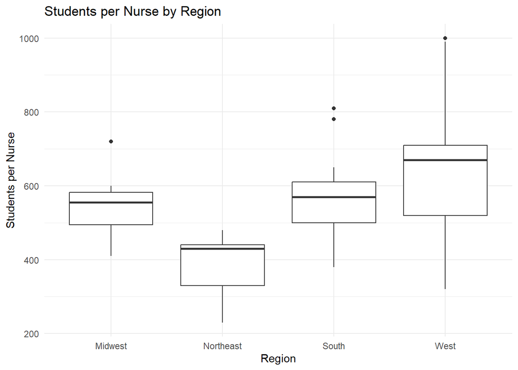

```r
dat_joined %>%
  filter(variable == "students_per_nurse")  %>%
  ggplot(aes(x = Region, y = value)) +
  geom_boxplot() +
  labs(title = "Students per Nurse by Region",
       x = "Region",
       y = "Students per Nurse") +
  theme_minimal()
```

## Rubric

|  | Points Possible | Points Earned |
| --- | --- | --- |
| File knits | 3 |  |
| Steps 1 and 3-10 completed | 3 points each |  |

## Knit and Submit

Complete the following steps to knit and publish your work:

1. First, change the name of the `author:` in the [YAML header](https://bookdown.org/yihui/rmarkdown-cookbook/rmarkdown-anatomy.html#yaml-metadata) at the very top of this document to your name. The YAML header controls the style and feel for knitted document but doesn’t actually display in the final output.
2. Next, click the knit button in the toolbar above to “knit” your R Markdown document to a [HTML](https://bookdown.org/yihui/rmarkdown/html-document.html) file that will be saved in your R Project folder. You should see a formatted webpage appear in your Viewer tab in the lower right pan or in a new browser window. Let’s us know if you run into any issues with knitting.
3. Upload the HTML file that is now present in the same folder as this R Markdown file to Canvas to receive credit for this assignment!